# ECO 602 Final Project: Data Analysis

Lina Clifford

2022-12-14

# Numerical Exploration

Summary statistics of body length and body mass:

```
##    Min. 1st Qu.  Median    Mean 3rd Qu.    Max.
##    49.0   106.0   116.0   114.7   124.0   265.0
```

```
##    Min. 1st Qu.  Median    Mean 3rd Qu.    Max.
##    5.00   35.00   43.00   44.06   54.00  105.00
```

Test normality of body length and body mass using the shapiro.test function:

```
##
##  Shapiro-Wilk normality test
##
## data:  delomys$body_length
## W = 0.87609, p-value < 2.2e-16
```

```
##
##  Shapiro-Wilk normality test
##
## data:  delomys$body_mass
## W = 0.99506, p-value = 4.33e-05
```

Since the p-values for both Shapiro tests are less than 0.05, we reject the null hypothesis and accept the alternative hypothesis which is that the data are NOT normally distributed.

# Questions 1 - 4: Graphical Exploration

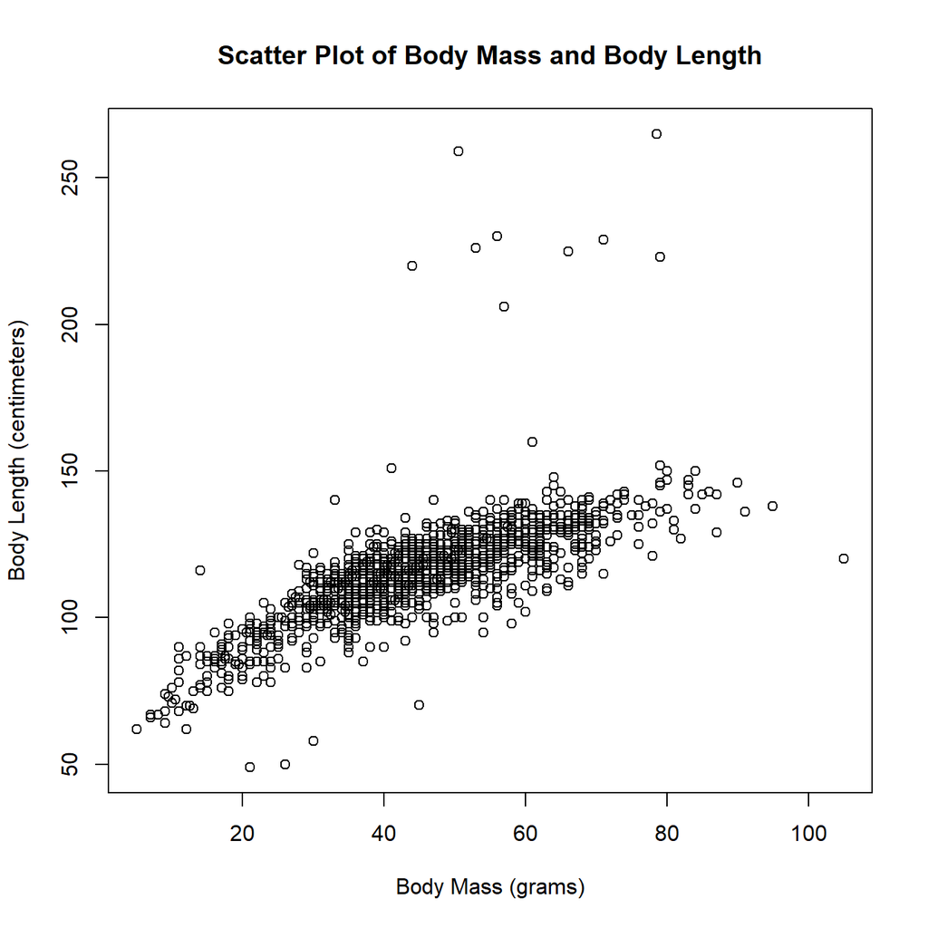

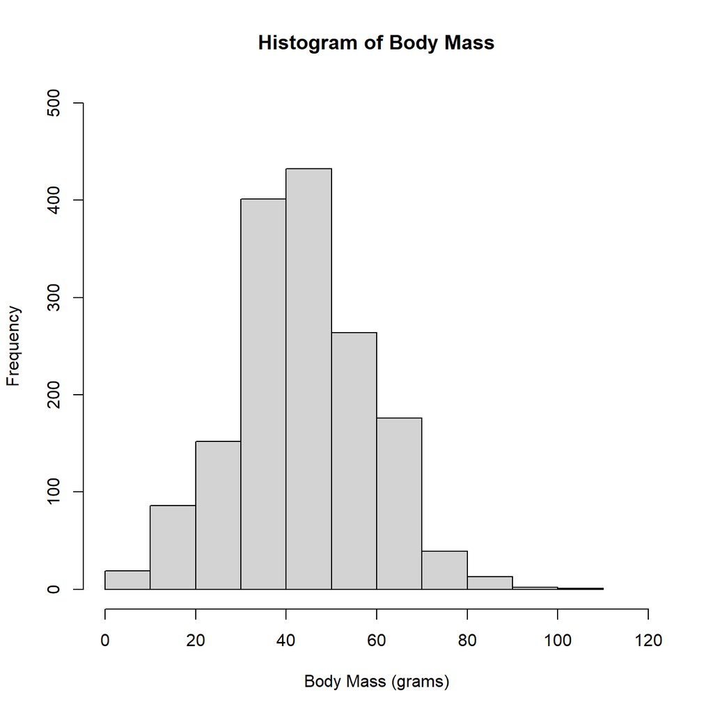

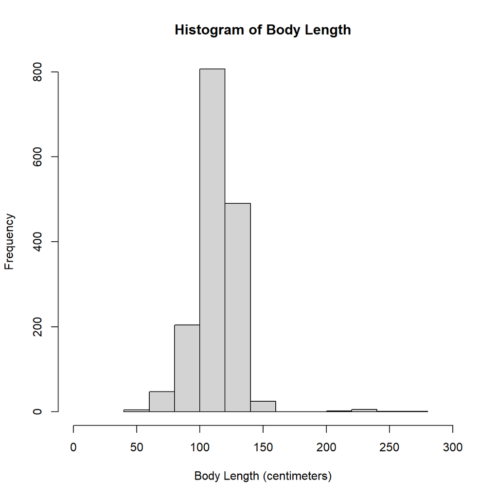

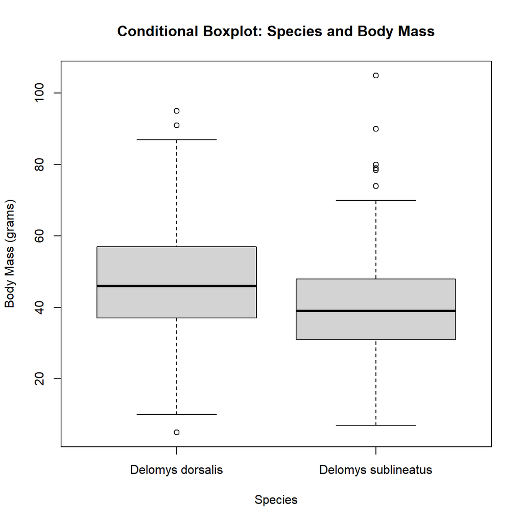

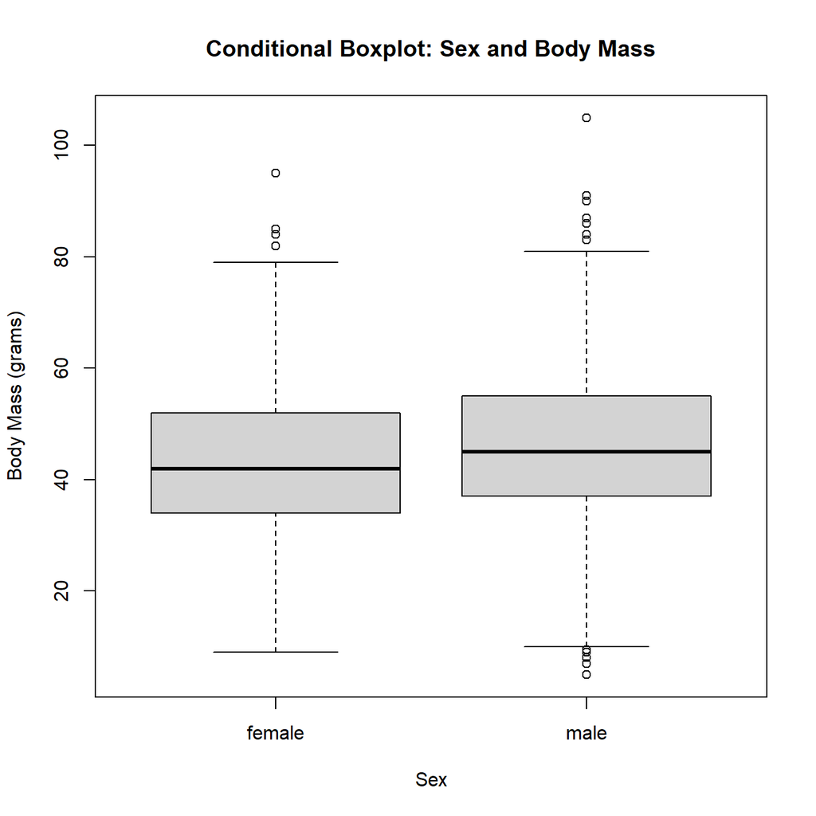

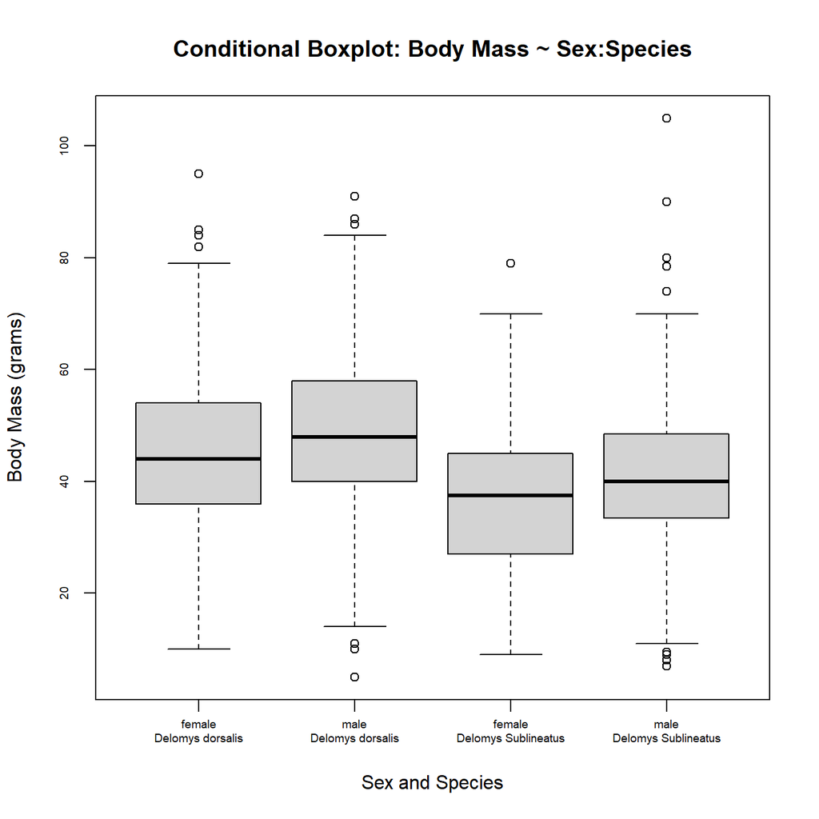

**Question 1: Qualitatively describe the relationship between body mass and length. Does the relationship seem linear, curved, nonexistent?**

There appears to be a linear relationship between body mass and body length, but this pattern is slightly weaker body masses of 65 and greater as there’s more variability.

**Question 2: Qualitatively describe the shapes of the histograms. Do the data appear normally-distributed? Explain why or why not. Explain why we care (or not) whether the data are normally distributed?**

The body mass data appears fairly normally distributed, but the body length data do not appear normally-distributed. The body mass histogram resembles a bell shaped distribution but the body length distribution is largely centered around a value of 120 and the histogram is very tall and skinny. We care that the data are normally distributed because normal distribution is a key assumption in some of the statistical tests we may want to run.

**Question 3: Using both the histograms and normality tests, do you think the (unconditioned) body masses and body length are normally-distributed? Make sure you contrast your visual assessment of normality to the results of the numerical normality tests.**

The normality test showed that neither the body mass or the body length data are normally distributed. The shape of the body length histogram also gives reason to believe that the data is not normally distributed, however the body mass histogram appears normally distributed. From the shapiro test and graphical analysis, I think both the body mass and body length data are not normally distributed.

**Question 4: Examine the three conditional boxplots.Describe any graphical evidence you see for body mass differences based on species and/or sex.**

Body mass seems to be greater for males and for the Delomys dorsalis species. This is apparent in all three conditional boxplots.

# Model Building

Fit five models using the lm() function